# Project 3

Project 3

Team - Data Domination

**Authors:** Nfn Tenzin Dakar, Nwe Oo Mon, Crystal Quezada

**Date:** 2024-10-20

## Members

- Nfn Tenzin Dakar
- Nwe Oo Mon (Nina)
- Crystal Quezada

## Description

Our group, DATA DOMINATION, will use Zoom and text messages for communication. All files, including data and documentation, are stored in a GitHub repo. We’ve created an entity-relationship diagram (ERD) using Mysql DataBase and identified our data sources, which will be loaded via CSV files from GitHub.

## Collaboration Tools

Our team leverages several tools to streamline collaboration and project development:

- R Markdown in RStudio Cloud: We use R Markdown to document our project, and publish the results through RPubs (rpubs.com), making our work easily accessible.
- MySQL : This tool was employed to design the entity-relationship diagram (ERD) for the project.
- [GitHub Repository](https://github.com/Nweoomon/Project3_607) : All source CSV files and R Markdown (RMD) files are stored centrally on GitHub, allowing the team to access and manage files efficiently.
- Communication: Our discussions and updates happen over Zoom for meetings and text messages for daily communication, ensuring smooth coordination.

## Sources

Kaggle ML & DS Survey: Our dataset is job listings based on software, which can be found on [Kaggle](https://www.kaggle.com/code/kerneler/starter-ds-job-listing-technology-04cdb0b7-0/input), it is also stored in our collaborative [GitHub repository](https://github.com/Nweoomon/Project3_607/blob/main/ds_job_listing_software.csv).

The dataset provides insights into the job market for data scientists in 2018, focusing on the demand for various programming languages and data tools across major job platforms, including LinkedIn, Indeed, SimplyHired, and Monster. It details the number of job postings that mention each keyword (e.g., Python, R, SQL) and calculates the percentage of total postings that each keyword represents on these platforms. Additionally, the dataset includes a comparison with 2017 data from Glassdoor.

## Entity Relationship Diagram

- Our diagram can be found on our shared [GitHub Repository](https://github.com/Nweoomon/Project3_607/blob/main/Job_listing_ERD_new.jpg).

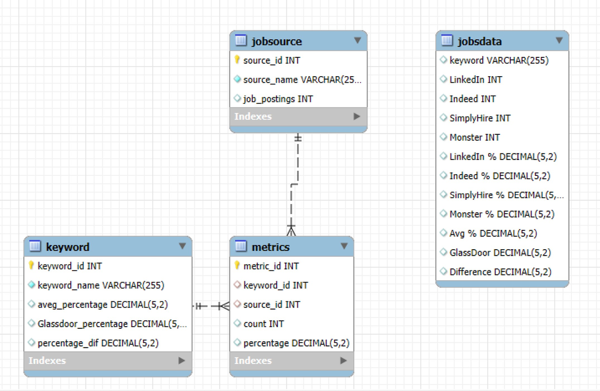

**Figure: Job_listing_ER Diagram**

The Keyword table stores the list of programming languages or technologies (e.g., Python, SQL, R), while the JobSource table holds different job platforms (e.g., LinkedIn, Indeed, Monster). The Metrics table acts as an associative entity that breaks down the many-to-many relationship between Keyword and Job Source into two one-to-many relationships.

- One-to-many between Keyword and Metrics:

For instance, “Python” can appear in multiple metrics entries, each representing a different job source (e.g., LinkedIn, Indeed).

- One-to-many between Job Source and Metrics:

For example, LinkedIn can have metrics for various keywords (e.g., Python, SQL, R).

- Metrics as the Associative Entity

Metrics has a foreign key to Keyword (keyword_id) and a foreign key to JobSource (source_id).

- Our sql codes can be found on our shared [GitHub Repository](https://github.com/Nweoomon/Project3_607/blob/main/Job_listing.sql).

## MySQL Data Import

Data from MySQL will be imported to R in following steps:

- Install and Load Necessary Packages: First, R packages DBI and RMariaDB are installed and loaded to connect and interact with the MySQL database.

```r
if (!requireNamespace("DBI", quietly = TRUE)) install.packages("DBI")
if (!requireNamespace("RMariaDB", quietly = TRUE)) install.packages("RMariaDB")
if (!requireNamespace("tidyverse", quietly = TRUE)) install.packages("tidyverse")
if (!requireNamespace("knitr", quietly = TRUE)) install.packages("knitr")
if (!requireNamespace("scales", quietly = TRUE)) install.packages("scales")

library(DBI)
library(RMariaDB)
library(tidyverse)
library(knitr)
library(scales)
```

- Store the Database Password Securely: To avoid exposing the database password in the code, the Password was stored in an environment file (.Renviron).
- Connect to the MySQL Database: Using dbConnect(), a connection will established to the MySQL database by providing the necessary credentials (user, password, database name, host, and port).
- Load Data from the Database: Once connected, SQL queries will be used to fetch data from specific tables. The result is stored in an R dataframe.
- Close the Connection: After loading the data, the database will be disconnected using dbDisconnect() to free up resources.

```r
con <- dbConnect(
  RMariaDB::MariaDB(),
  user = 'root',
  password = Sys.getenv("MYSQL_PWD"),
  dbname = 'job_listing',
  host = 'localhost',
  port = 3306
)

# Check if the connection is successful
if (!is.null(con)) {
  print("Connected successfully!")
} else {
  print("Connection failed.")
}
```

```
## [1] "Connected successfully!"
```

```r
# Load the data from the MySQL table into an R dataframe
jobsource <- dbGetQuery(con, "SELECT * FROM jobsource")
keyword <- dbGetQuery(con, "SELECT * FROM keyword")
metrics <- dbGetQuery(con, "SELECT * FROM metrics")

# Execute the SQL query and fetch the results into an R data frame
query <- "SELECT keyword.keyword_name,
                jobsource.source_name,
                metrics.count,
                metrics.percentage
        FROM metrics
        JOIN jobsource ON metrics.source_id = jobsource.source_id
        JOIN keyword ON metrics.keyword_id = keyword.keyword_id;"

# Fetch the data
metrics_combined <- dbGetQuery(con, query)

# Display the results
glimpse (metrics_combined)
```

```
## Rows: 148
## Columns: 4
## $ keyword_name <chr> "Python", "R", "SQL", "Spark", "Hadoop", "Java", "SAS", "…
## $ source_name  <chr> "Indeed", "Indeed", "Indeed", "Indeed", "Indeed", "Indeed…
## $ count        <int> 3818, 3106, 2628, 1551, 1578, 1377, 1134, 1012, 830, 739,…
## $ percentage   <dbl> 0.74, 0.60, 0.51, 0.30, 0.31, 0.27, 0.22, 0.20, 0.16, 0.1…
```

```r
# Close the database connection
dbDisconnect(con)
```

## Data Clean Up, Formatting and Transformation

- Database Design: The SQL database was structured with normalized tables, using appropriate data types—VARCHAR for text fields, INT for numerical fields, and DECIMAL for percentage values. This approach ensured efficient and accurate data storage and retrieval.
- Data Cleaning: Before loading data into SQL, the CSV file underwent thorough pre-processing in Excel. This included removing commas from numeric fields, converting percentage formats to numbers, filling empty cells with -1 to denote missing values, and removing redundant rows like “Total.” These steps ensured that the data was clean and aligned with the database requirements.
- Data Loading: The cleaned data was then imported into SQL tables. The NULLIF function was used to handle missing or invalid data, converting any -1 entries to NULL during the import process, which maintained data integrity.
- Normalization and Relationships: The database design incorporated normalization techniques to minimize data redundancy, enhancing data efficiency. Foreign keys were used to establish clear relationships between tables, improving data integration and consistency.

## Data Analysis

#### Job Postings Analysis

- The first plot illustrates the total number of job postings across each job source. LinkIn has the most job postings.

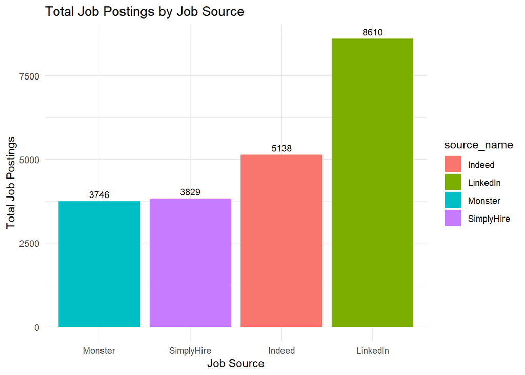

```r
ggplot(jobsource, aes(x = reorder(source_name, job_postings), y = job_postings, fill = source_name)) +
  geom_bar(stat = "identity") +
  labs(x = "Job Source", y = "Total Job Postings", title = "Total Job Postings by Job Source") +
  theme_minimal() +
  geom_text(aes(label = job_postings), vjust = -0.5, size = 3)
```

#### Demands across Job sources

- The heatmap visualizes the demand for tools across different platforms (SimplyHired, Indeed, LinkedIn, and Monster) based on their respective percentages.
- The heatmap provides a quick overview of how different tools are distributed in terms of demand across multiple platforms,

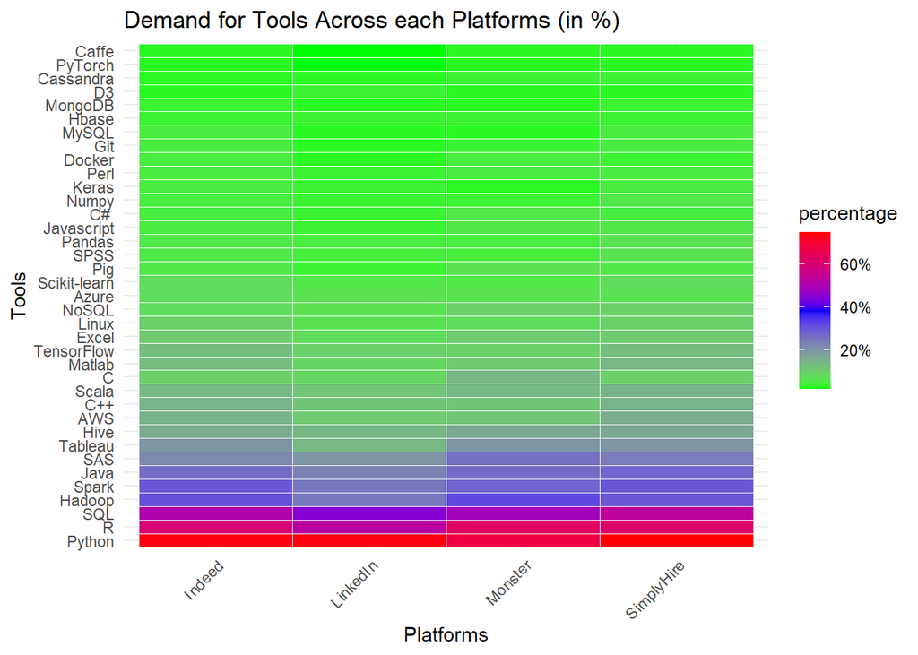

```r
# Sort the data by 'percentage' in descending order
metrics_combined <- metrics_combined %>%
  arrange(desc(percentage))

# Convert 'keyword_name' to a factor based on the sorted order
metrics_combined$keyword_name <- factor(metrics_combined$keyword_name, levels = unique(metrics_combined$keyword_name))

# Create the heatmap with the corrected order and color gradient
ggplot(metrics_combined, aes(x = source_name, y = keyword_name, fill = percentage)) +
  geom_tile(color = "white") +
  scale_fill_gradientn(colors = c("green", "blue", "red"),
                       values = scales::rescale(c(0, 0.5, 1)),
                       labels = scales::percent_format(accuracy = 1)) +
  labs(title = "Demand for Tools Across each Platforms (in %)",
       x = "Platforms",
       y = "Tools") +
  theme_minimal() +
  theme(axis.text.x = element_text(angle = 45, hjust = 1))
```

#### Top and Bottom skills

- The top 5 and bottom 5 skills based on their average percentage of appearance across different job sources are presented with a barchart. The average percentage indicates how frequently each skill appears in job postings on platforms like LinkedIn, Indeed, SimplyHired, and Monster. The percentage was calculated for each skill on each platform and then averaged across all platforms.
- The results highlight a clear preference for fundamental data science tools and programming languages, like Python, R, and SQL, across job postings. In contrast, more niche or emerging tools like Keras, PyTorch, etc are less frequently required.

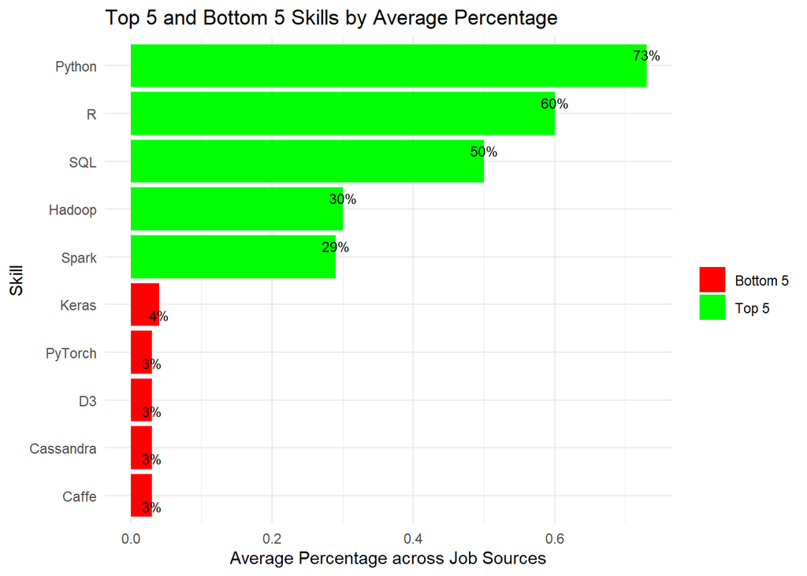

```r
# Filter top 5 and bottom 5 skills by average percentage
top_skills <- keyword %>%
  arrange(desc(aveg_percentage)) %>%
  head(5)

bottom_skills <- keyword %>%
  arrange(aveg_percentage) %>%
  head(5)

# Combine top and bottom skills into one data frame
top_bottom_skills <- rbind(top_skills, bottom_skills)

# Create a new column to indicate the color
top_bottom_skills$color <- ifelse(top_bottom_skills$aveg_percentage %in% top_skills$aveg_percentage, "Top 5", "Bottom 5")

# Plotting
ggplot(top_bottom_skills, aes(x = reorder(keyword_name, aveg_percentage), y = aveg_percentage, fill = color)) +
  geom_bar(stat = "identity") +
  scale_fill_manual(values = c("Top 5" = "green", "Bottom 5" = "red")) +
  labs(x = "Skill", y = "Average Percentage across Job Sources", title = "Top 5 and Bottom 5 Skills by Average Percentage", fill = "") +
  theme_minimal() +
 geom_text(aes(label = percent(aveg_percentage, accuracy = 1)), vjust = ifelse(top_bottom_skills$color == "Top 5", -0.5, 1.5), size = 3) +
  coord_flip()
```

#### Top 5 skills (in counts)

- The faceted bar chart shows the top tools by demand across four job listing platforms: SimplyHired, Indeed, LinkedIn, and Monster.
- Python, R, and SQL are the dominant tools across platforms, highlighting their importance in the data science job market.
- The higher demand on LinkedIn suggests it may be a preferred platform for recruiting data science professionals.

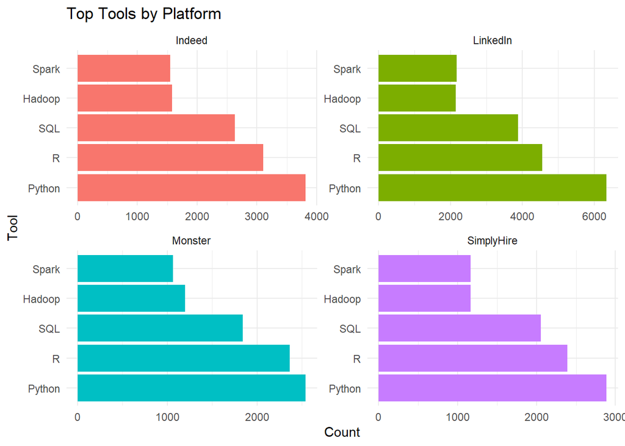

```r
# Sort the data to get top tools per platform
top_tools <- metrics_combined %>%
  group_by(source_name) %>%
  top_n(5, wt = count) %>%
  ungroup()

# Create the faceted bar chart
ggplot(top_tools, aes(x = reorder(keyword_name, -count), y = count, fill = source_name)) +
  geom_bar(stat = "identity") +
  facet_wrap(~ source_name, scales = "free") +  # Facet by source_name (platform)
  coord_flip() +  # Flip coordinates for horizontal bars
  labs(title = "Top Tools by Platform",
       x = "Tool",
       y = "Count") +
  theme_minimal() +
  theme(legend.position = "none")  # Remove the legend since we already use facets
```

#### Changes from 2017

- The average percentage of skill mentions in 2018 across job platforms (LinkedIn, Indeed, SimplyHired, Monster) are compared with the 2017 Glassdoor data for the some skills.
- The data shows a shift in focus from older, more traditional tools (like Hadoop, SAS, and Matlab) towards newer or more versatile tools (like Python, Spark, and Tableau).

```r
# Filter out rows with NA values in the 'percentage_dif' column
data_filtered <- keyword %>%
  filter(!is.na(percentage_dif))

# Display the data frame
kable(data_filtered, caption = "Filtered Data")
```

Filtered Data

| keyword_id | keyword_name | aveg_percentage | Glassdoor_percentage | percentage_dif |
| --- | --- | --- | --- | --- |
| 1 | Python | 0.73 | 0.72 | 0.01 |
| 2 | R | 0.60 | 0.64 | -0.04 |
| 3 | SQL | 0.50 | 0.51 | -0.01 |
| 4 | Spark | 0.29 | 0.27 | 0.02 |
| 5 | Hadoop | 0.30 | 0.39 | -0.09 |
| 6 | Java | 0.26 | 0.33 | -0.07 |
| 7 | SAS | 0.23 | 0.30 | -0.07 |
| 8 | Tableau | 0.19 | 0.14 | 0.05 |
| 9 | Hive | 0.16 | 0.17 | -0.01 |
| 14 | Matlab | 0.12 | 0.20 | -0.08 |

[figure not shown]

```r
# Plotting
ggplot(data_filtered, aes(x = reorder(keyword_name, percentage_dif), y = percentage_dif, fill = percentage_dif > 0)) +
  geom_bar(stat = "identity") +
  scale_fill_manual(values = c("TRUE" = "green", "FALSE" = "red"), labels = c("Positive Change", "Negative Change")) +
  labs(x = "Skill", y = "Percentage Difference from 2017 Glassdoor Postings", title = "Percentage Difference (2018 Average vs 2017 Glassdoor)") +
  theme_minimal() +
  geom_text(aes(label = scales::percent(percentage_dif, accuracy = 1)),
            vjust = 0.5, hjust = ifelse(data_filtered$percentage_dif > 0, -0.1, 1.1), size = 3.0) +
  coord_flip()
```

#### Correlation Analysis between platforms

- The table presents the correlation matrix among job postings for the four platforms: Indeed, LinkedIn, Monster, and SimplyHired.
- The correlation values are very high, ranging from 0.98 to 0.99, indicating a strong positive correlation between job postings on these platforms.
- This matrix indicates that the job market for data science roles exhibits similar trends across the four job platforms

```r
metrics_count <- metrics_combined %>%
  select(-percentage)

# Pivot the data to a wide format based on 'source_name'
wide_data_count <- metrics_count %>%
  pivot_wider(names_from = source_name, values_from = count)

# View the reshaped data
print(wide_data_count)
```

```
## # A tibble: 37 × 5
##    keyword_name SimplyHire Indeed LinkedIn Monster
##    <fct>             <int>  <int>    <int>   <int>
##  1 Python             2888   3818     6347    2544
##  2 R                  2393   3106     4553    2365
##  3 SQL                2056   2628     3879    1841
##  4 Hadoop             1164   1578     2142    1200
##  5 Spark              1167   1551     2169    1062
##  6 Java               1059   1377     1944    1002
##  7 SAS                 910   1134     1713     978
##  8 Tableau             780   1012     1216     744
##  9 Hive                637    830     1182     619
## 10 AWS                 607    791      947     467
## # ℹ 27 more rows
```

```r
# Compute the Pearson correlation matrix
cor_matrix <- cor(wide_data_count [,-1], use = "complete.obs", method = "pearson")

# Print the correlation matrix
print(cor_matrix)
```

```
##            SimplyHire    Indeed  LinkedIn   Monster
## SimplyHire  1.0000000 0.9993663 0.9941885 0.9933402
## Indeed      0.9993663 1.0000000 0.9948814 0.9928074
## LinkedIn    0.9941885 0.9948814 1.0000000 0.9858190
## Monster     0.9933402 0.9928074 0.9858190 1.0000000
```

## Conclusion

- The analysis shows that Python, R, and SQL are the most in-demand tools across the four major job platforms (SimplyHired, Indeed, LinkedIn, and Monster).
- Python consistently ranks as the top skill, followed closely by R and SQL, indicating strong demand for these core programming languages in data science roles.
- The higher counts observed on LinkedIn suggest that it may be a key platform for job seekers in the data science field.
- Meanwhile, big data tools like Hadoop and Spark are also popular but have fewer listings compared to general-purpose programming languages.
- This trend highlights the importance of Python, R, and SQL in the current job market, making them critical skills for aspiring data scientists to master.